# Acoustics Only Models - Neg Binomial

Yvonne Barkley

10/4/2020

Load libraries

```r
library(tidyverse)
library(mgcv)
library(corrplot)
library(geoR)
library(tidymv)
library(here)
```

# Research question:

## What environmental variables characterize sperm whale habitat?

## Hypothesis: Sperm whales are found in deep, productive offshore waters.

Load universal variables

```r
# Values used for file and directory names
survey = "AllSurveys"
gridsize = 25
loctype = "AcOnly"
loctype2 = "Ac"
```

Load data from ‘models/data’ folder

```r
PmScaled <- readRDS(here::here(paste0("output/models/", loctype,
    "/data/", "CompletePm_", gridsize, "km_", loctype2, "_scaled.rda")))
# add column for log effort as offset #
PmScaled$log.effort = log(PmScaled$EffArea)
PmScaled <- subset(PmScaled, chla <= 10)  #some outliers in a handful of absences
```

Check correlation of covariates

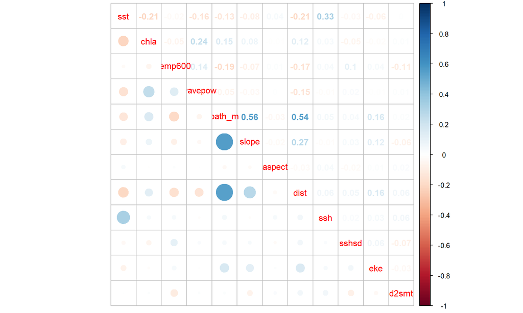

```r
require(corrplot)
corrplot.mixed(cor(PmScaled[, 18:29]), upper = "number", lower = "circle")
```

```r
# Are all correlation coefficients < |0.6|?
abs(cor(PmScaled[, 18:29])) <= 0.6
```

```
          sst  chla temp600 wavepow bath_m slope aspect  dist   ssh sshsd   eke
sst     FALSE  TRUE    TRUE    TRUE   TRUE  TRUE   TRUE  TRUE  TRUE  TRUE  TRUE
chla     TRUE FALSE    TRUE    TRUE   TRUE  TRUE   TRUE  TRUE  TRUE  TRUE  TRUE
temp600  TRUE  TRUE   FALSE    TRUE   TRUE  TRUE   TRUE  TRUE  TRUE  TRUE  TRUE
wavepow  TRUE  TRUE    TRUE   FALSE   TRUE  TRUE   TRUE  TRUE  TRUE  TRUE  TRUE
bath_m   TRUE  TRUE    TRUE    TRUE  FALSE  TRUE   TRUE  TRUE  TRUE  TRUE  TRUE
slope    TRUE  TRUE    TRUE    TRUE   TRUE FALSE   TRUE  TRUE  TRUE  TRUE  TRUE
aspect   TRUE  TRUE    TRUE    TRUE   TRUE  TRUE  FALSE  TRUE  TRUE  TRUE  TRUE
dist     TRUE  TRUE    TRUE    TRUE   TRUE  TRUE   TRUE FALSE  TRUE  TRUE  TRUE
ssh      TRUE  TRUE    TRUE    TRUE   TRUE  TRUE   TRUE  TRUE FALSE  TRUE  TRUE
sshsd    TRUE  TRUE    TRUE    TRUE   TRUE  TRUE   TRUE  TRUE  TRUE FALSE  TRUE
eke      TRUE  TRUE    TRUE    TRUE   TRUE  TRUE   TRUE  TRUE  TRUE  TRUE FALSE
d2smt    TRUE  TRUE    TRUE    TRUE   TRUE  TRUE   TRUE  TRUE  TRUE  TRUE  TRUE
        d2smt
sst      TRUE
chla     TRUE
temp600  TRUE
wavepow  TRUE
bath_m   TRUE
slope    TRUE
aspect   TRUE
dist     TRUE
ssh      TRUE
sshsd    TRUE
eke      TRUE
d2smt   FALSE
```

### KS tests

I compared the distributions of environmental data between the whales and the absences. Plots are attached in separate powerpoint. In summary, temperature at 600 m, SSH, and chlorophyll were the only variables with significantly different distributions (p-value < 0.05). However, the D statistics were close to zero (D ~ 0.1) for each, indicating that although the distributions were different, they were not that far apart. The plots also show how similar the general shape of the distributions are between where the whales were observed and where they were absent.

### Data Visualization

Histograms showing the general distribution of each environmental predictor for the entire dataset.

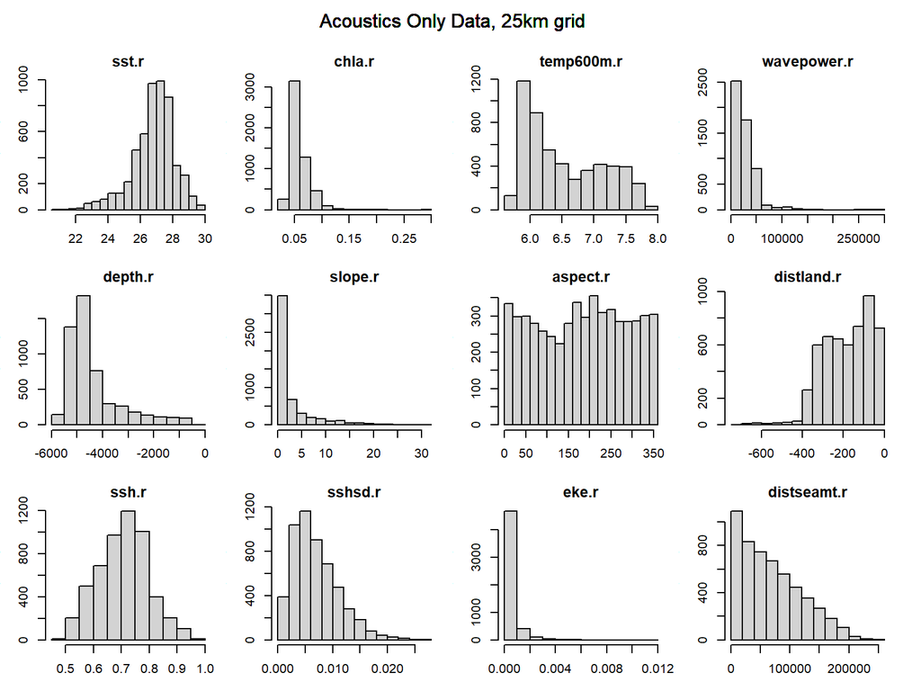

```r
par(mfrow = c(3, 4), mar = c(3, 3, 2, 1), oma = c(0, 0, 3, 1))

dataSet = PmScaled  #raw values

loopVec <- 30:41  #columns from PmScaled to plot

for (j in loopVec) {

    datPlot <- dataSet[, c(1, j)]

    hist(datPlot[, 2], main = colnames(datPlot)[2], ylab = "frequency",
        xlab = "")
    # plot(datPlot[,2], datPlot[,1], ylab = 'Whales', xlab =
    # colnames(datPlot)[2])
    mtext(paste0("Acoustics Only Data, ", gridsize, "km grid"),
        side = 3, line = 1, outer = TRUE, cex = 1, font = 1)

}
```

```r
# dev.off()
```

```r
# take the log of some variables that are more skewed
PmScaled$chla.log <- log(PmScaled$chla.r)
PmScaled$eke.log <- log(PmScaled$eke.r)
PmScaled$wavepow.log <- log(PmScaled$wavepower.r)


# plot them
dataSet = PmScaled  #raw values

loopVec <- 57:59  #columns from PmScaled to plot

par(mfrow = c(1, 3), mar = c(3, 3, 2, 1), oma = c(0, 0, 3, 1))

for (j in loopVec) {

    datPlot <- dataSet[, c(1, j)]

    hist(datPlot[, 2], main = colnames(datPlot)[2], ylab = "frequency",
        xlab = "")
    # plot(datPlot[,2], datPlot[,1], ylab = 'Whales', xlab =
    # colnames(datPlot)[2])
    mtext(paste0("Acoustics Only Data, ", surveynum, ", ", gridsize,
        "km grid"), side = 3, line = 1, outer = TRUE, cex = 1,
        font = 1)

}
```

[output not shown]

### Data Splitting

Split the data into train and test sets

```r
require(dplyr)
splitdf <- function(dataframe, seed = NULL) {
    if (!is.null(seed))
        set.seed(seed)
    index <- 1:nrow(dataframe)
    trainindex <- sample(index, trunc(length(index) * 0.7))
    trainset <- dataframe[trainindex, ]
    testset <- dataframe[-trainindex, ]
    list(trainset = trainset, testset = testset)
}

trainAcOnly = NULL
testAcOnly = NULL
seed = 1

for (s in c(1641, 1303, 1604, 1705, 1706)) {

    trSub <- filter(PmScaled, survey == s)

    # subset for presences and split 70/30
    pres1 <- filter(trSub, pa > 0 & sid == 999)  # & loc == 1) #for S999 versions
    listPres <- splitdf(pres1, seed)  #output is list for train and test

    # subset for absences and split 70/30
    abs0 <- filter(trSub, pa == 0)
    listAbs <- splitdf(abs0, seed)  #output is list for train and test

    # combine train data for presence and absence
    trainAll <- rbind(listPres$trainset, listAbs$trainset)

    # combine test data for presence and absence
    testAll <- rbind(listPres$testset, listAbs$testset)

    trainAcOnly = rbind(trainAcOnly, trainAll)
    testAcOnly = rbind(testAcOnly, testAll)

    # trainAcOnly$log.effort <- log(trainAcOnly$EffArea)
    # testAcOnly$log.effort <- log(testAcOnly$EffArea)
}
saveRDS(trainAcOnly, here::here(paste0("output/models/", loctype,
    "/data/Train_", gridsize, "km_", loctype2, "_S999b.rda")))
saveRDS(testAcOnly, here::here(paste0("output/models/", loctype,
    "/data/Test_", gridsize, "km_", loctype2, "_S999b.rda")))

# nrow(dplyr::filter(trainAcOnly, trainAcOnly$pa >0))
# nrow(dplyr::filter(testAcOnly, testAcOnly$pa >0))
```

## Generalized Additive Models

The data are treated as count data, number of sperm whale encounters per cell, and we used the negative binomial distribution to model the response variable for comparison with the Tweedie distribution. We used thin-plate regression splines (the default basis) for the smoothers of the environmental predictors. Each smoother was limited to 3 degrees of freedom (k=3) to reduce overfitting parameters per recommendations from other studies building similar types of cetaceans distribution models.The log of the effort was included as an offset to account for the variation in effort per cell.

### 25 km spatial scale

- NEGATIVE BINOMIAL DISTRIBUTION
- Knots contrained to k=3 according to literature on cetacean distribution models.
- Automatic term selection is uses an additional penalty term when determining the smoothness of the function (‘select’ argument = TRUE)..
- We excluded all non-significant variables (alpha=0.05) and refit the models until all variables were significant.
- REML is restricted maximum likelihood used to optimize the parameter estimates.

Load training and test data

```r
# seed 1
trainS999 <- readRDS(here::here(paste0("output/models/", loctype,
    "/data/Train_", gridsize, "km_", loctype2, "_S999b.rda")))
testS999 <- readRDS(here::here(paste0("output/models/", loctype,
    "/data/Test_", gridsize, "km_", loctype2, "_S999b.rda")))
```

## **Model Selection**

### FULL MODEL

Estimate the smoothing parameters for each predictor variable using restricted maximum likelihood (method = ‘REML’) + does not include spatial smoother + does not include slope or aspect due to the variation between left and right

Using the scaled values

```r
# * Does NOT include sighted acoustic encounters OR spatial
# smoother
require(mgcv)
nbS999 <- gam(pa ~ s(bath_m, k = 3) + s(dist, k = 3) + s(d2smt,
    k = 3) + s(sst, k = 3) + s(chla, k = 3) + s(temp600, k = 3) +
    s(ssh, k = 3) + s(sshsd, k = 3) + s(eke, k = 3) + s(wavepow,
    k = 3) + offset(log.effort), data = trainS999, family = nb,
    link = "log", select = TRUE, method = "REML")
summary(nbS999)
```

```
Family: Negative Binomial(0.429)
Link function: log

Formula:
pa ~ s(bath_m, k = 3) + s(dist, k = 3) + s(d2smt, k = 3) + s(sst,
    k = 3) + s(chla, k = 3) + s(temp600, k = 3) + s(ssh, k = 3) +
    s(sshsd, k = 3) + s(eke, k = 3) + s(wavepow, k = 3) + offset(log.effort)

Parametric coefficients:
            Estimate Std. Error z value Pr(>|z|)
(Intercept) -22.9302     0.1195  -191.9   <2e-16 ***
---
Signif. codes:  0 '***' 0.001 '**' 0.01 '*' 0.05 '.' 0.1 ' ' 1

Approximate significance of smooth terms:
                 edf Ref.df Chi.sq  p-value
s(bath_m)  8.004e-01      2  4.022 0.023926 *
s(dist)    6.496e-01      2  1.846 0.089364 .
s(d2smt)   1.108e-01      2  0.121 0.294713
s(sst)     6.827e-01      2  2.014 0.082015 .
s(chla)    8.125e-01      2  4.062 0.023203 *
s(temp600) 9.086e-01      2  9.910 0.000738 ***
s(ssh)     9.258e-01      2 12.247 0.000267 ***
s(sshsd)   7.250e-01      2  2.670 0.054397 .
s(eke)     8.597e-01      2  5.345 0.012116 *
s(wavepow) 7.488e-06      2  0.000 0.944846
---
Signif. codes:  0 '***' 0.001 '**' 0.01 '*' 0.05 '.' 0.1 ' ' 1

R-sq.(adj) =  0.0414   Deviance explained = 10.5%
-REML = 424.19  Scale est. = 1         n = 3659
```

```r
# + s(slope, k=3) + s(aspect, k=3) # removed 9/27
```

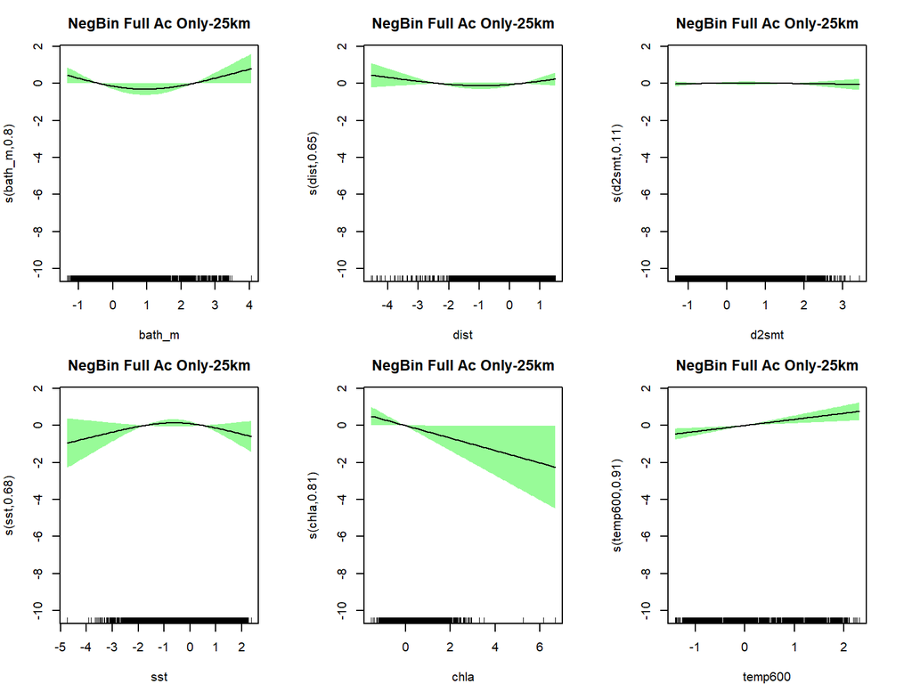

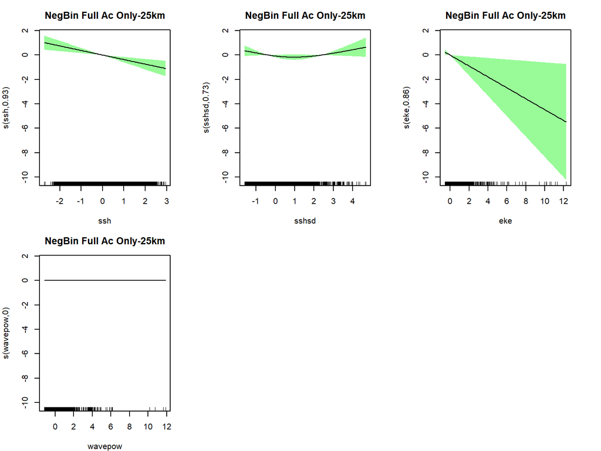

#### MODEL DIAGNOSTICS

The stripe at the bottom left of the residuals vs. fitted values (linear predictor) corresponds to the zeros.

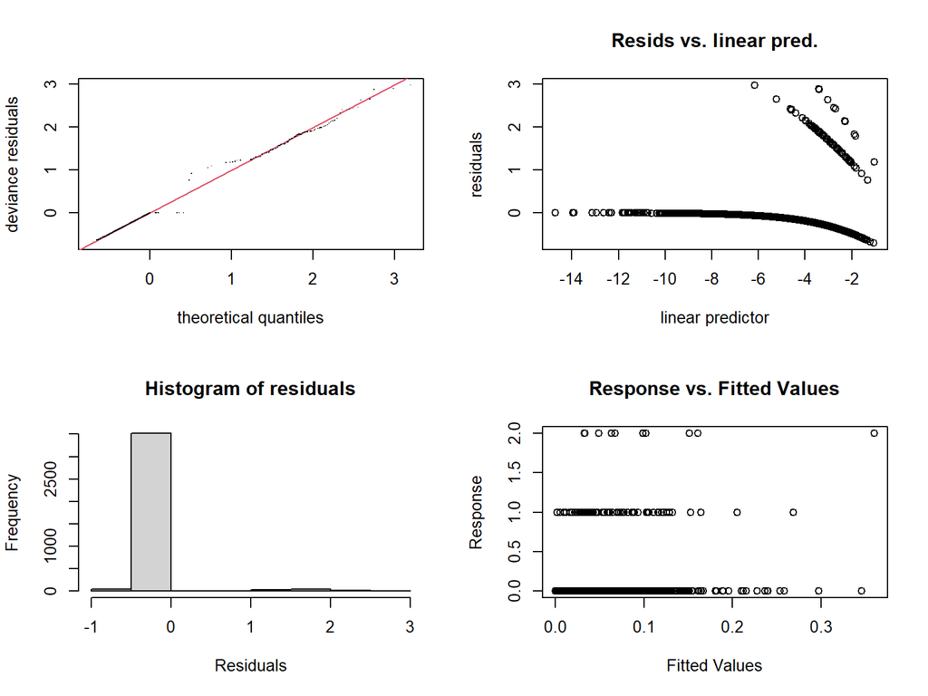

```
Method: REML   Optimizer: outer newton
full convergence after 14 iterations.
Gradient range [-6.672544e-05,1.57489e-05]
(score 424.1868 & scale 1).
Hessian positive definite, eigenvalue range [1.516209e-06,4.191952].
Model rank =  21 / 21

Basis dimension (k) checking results. Low p-value (k-index<1) may
indicate that k is too low, especially if edf is close to k'.

                 k'      edf k-index p-value
s(bath_m)  2.00e+00 8.00e-01    0.82   0.055 .
s(dist)    2.00e+00 6.50e-01    0.85   0.650
s(d2smt)   2.00e+00 1.11e-01    0.85   0.695
s(sst)     2.00e+00 6.83e-01    0.81   0.015 *
s(chla)    2.00e+00 8.12e-01    0.84   0.365
s(temp600) 2.00e+00 9.09e-01    0.73  <2e-16 ***
s(ssh)     2.00e+00 9.26e-01    0.84   0.135
s(sshsd)   2.00e+00 7.25e-01    0.82   0.050 *
s(eke)     2.00e+00 8.60e-01    0.84   0.210
s(wavepow) 2.00e+00 7.49e-06    0.78  <2e-16 ***
---
Signif. codes:  0 '***' 0.001 '**' 0.01 '*' 0.05 '.' 0.1 ' ' 1
```

### REDUCE MODEL PARAMETERS

```r
# * Does NOT include sighted acoustic encounters

nbS999b <- gam(pa ~ s(bath_m, k = 3) + s(temp600, k = 3) + s(ssh,
    k = 3) + s(sshsd, k = 3) + s(eke, k = 3) + s(wavepow, k = 3) +
    offset(log.effort), data = trainS999, family = nb, link = "log",
    select = TRUE, method = "REML")
summary(nbS999b)
```

```
Family: Negative Binomial(0.394)
Link function: log

Formula:
pa ~ s(bath_m, k = 3) + s(temp600, k = 3) + s(ssh, k = 3) + s(sshsd,
    k = 3) + s(eke, k = 3) + s(wavepow, k = 3) + offset(log.effort)

Parametric coefficients:
            Estimate Std. Error z value Pr(>|z|)
(Intercept) -22.8779     0.1156  -197.9   <2e-16 ***
---
Signif. codes:  0 '***' 0.001 '**' 0.01 '*' 0.05 '.' 0.1 ' ' 1

Approximate significance of smooth terms:
                 edf Ref.df Chi.sq  p-value
s(bath_m)  8.371e-01      2  5.172 0.012348 *
s(temp600) 1.130e+00      2  7.478 0.003994 **
s(ssh)     9.340e-01      2 13.976 0.000108 ***
s(sshsd)   6.783e-01      2  2.151 0.074580 .
s(eke)     8.574e-01      2  5.250 0.013274 *
s(wavepow) 1.919e-05      2  0.000 0.710937
---
Signif. codes:  0 '***' 0.001 '**' 0.01 '*' 0.05 '.' 0.1 ' ' 1

R-sq.(adj) =  0.0362   Deviance explained = 8.93%
-REML = 425.63  Scale est. = 1         n = 3659
```

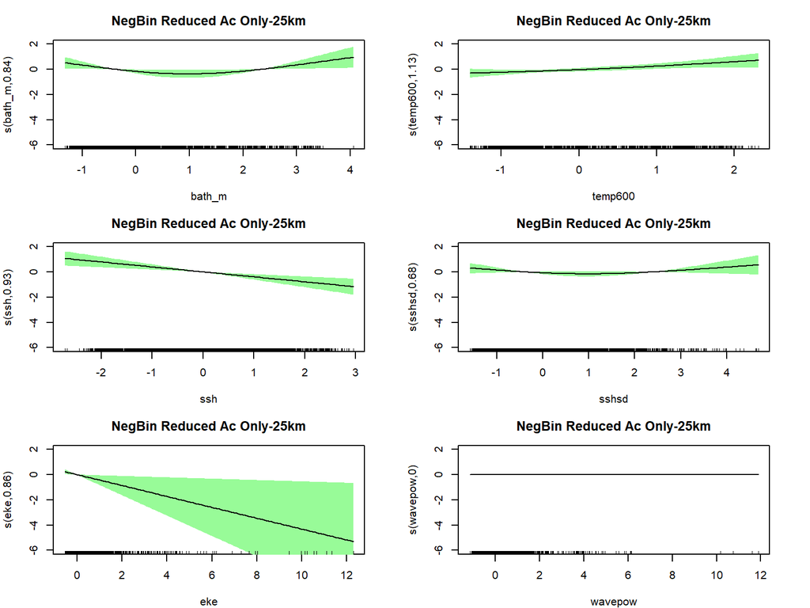

- Remove wave power
- Remove sshsd

```r
# * Does NOT include sighted acoustic encounters

nbS999c <- gam(pa ~ s(bath_m, k = 3) + s(temp600, k = 3) + s(ssh,
    k = 3) + s(eke, k = 3) + offset(log.effort), data = trainS999,
    family = nb, link = "log", select = TRUE, method = "REML")
summary(nbS999c)
```

```
Family: Negative Binomial(0.368)
Link function: log

Formula:
pa ~ s(bath_m, k = 3) + s(temp600, k = 3) + s(ssh, k = 3) + s(eke,
    k = 3) + offset(log.effort)

Parametric coefficients:
            Estimate Std. Error z value Pr(>|z|)
(Intercept) -22.8702     0.1157  -197.6   <2e-16 ***
---
Signif. codes:  0 '***' 0.001 '**' 0.01 '*' 0.05 '.' 0.1 ' ' 1

Approximate significance of smooth terms:
              edf Ref.df Chi.sq  p-value
s(bath_m)  0.8509      2  5.754 0.008932 **
s(temp600) 0.9993      2  6.817 0.005356 **
s(ssh)     0.9343      2 14.059 0.000103 ***
s(eke)     0.8620      2  5.471 0.011726 *
---
Signif. codes:  0 '***' 0.001 '**' 0.01 '*' 0.05 '.' 0.1 ' ' 1

R-sq.(adj) =  0.0323   Deviance explained = 8.41%
-REML = 426.13  Scale est. = 1         n = 3659
```

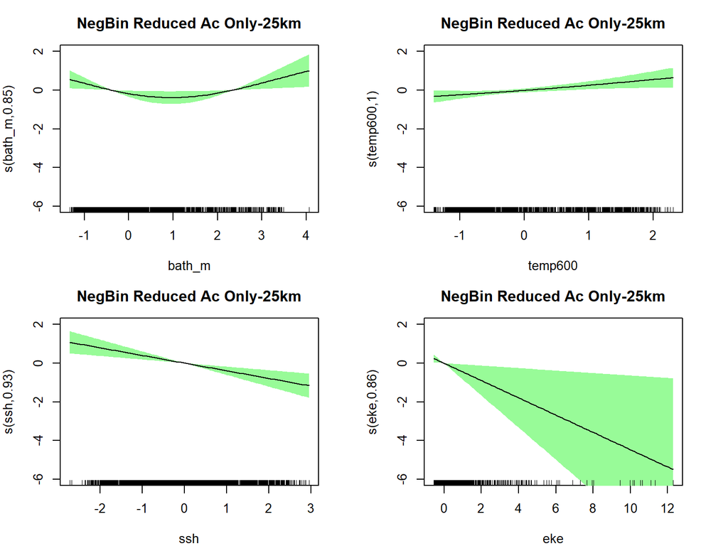

#### MODEL DIAGNOSTICS

Check the residuals and smooth parameters.

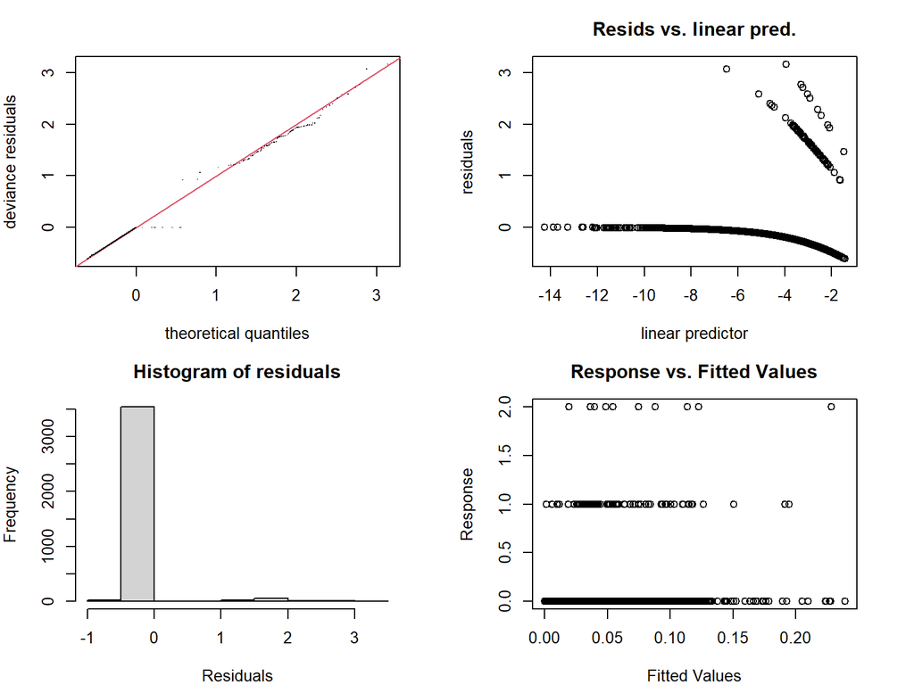

```
Method: REML   Optimizer: outer newton
full convergence after 12 iterations.
Gradient range [-8.70497e-05,5.662692e-06]
(score 426.1267 & scale 1).
Hessian positive definite, eigenvalue range [1.799498e-05,4.765316].
Model rank =  9 / 9

Basis dimension (k) checking results. Low p-value (k-index<1) may
indicate that k is too low, especially if edf is close to k'.

              k'   edf k-index p-value
s(bath_m)  2.000 0.851    0.81    0.03 *
s(temp600) 2.000 0.999    0.72  <2e-16 ***
s(ssh)     2.000 0.934    0.83    0.16
s(eke)     2.000 0.862    0.83    0.19
---
Signif. codes:  0 '***' 0.001 '**' 0.01 '*' 0.05 '.' 0.1 ' ' 1
```

## Include 2D Lat-Lon

```r
nbS999LL <- gam(pa ~ s(Longitude, Latitude) + s(bath_m, k = 3) +
    s(dist, k = 3) + s(d2smt, k = 3) + s(sst, k = 3) + s(chla,
    k = 3) + s(temp600, k = 3) + s(ssh, k = 3) + s(sshsd, k = 3) +
    s(eke, k = 3) + s(wavepow, k = 3) + offset(log.effort), data = trainS999,
    family = nb, link = "log", select = TRUE, method = "REML")
summary(nbS999LL)
```

```
Family: Negative Binomial(0.536)
Link function: log

Formula:
pa ~ s(Longitude, Latitude) + s(bath_m, k = 3) + s(dist, k = 3) +
    s(d2smt, k = 3) + s(sst, k = 3) + s(chla, k = 3) + s(temp600,
    k = 3) + s(ssh, k = 3) + s(sshsd, k = 3) + s(eke, k = 3) +
    s(wavepow, k = 3) + offset(log.effort)

Parametric coefficients:
            Estimate Std. Error z value Pr(>|z|)
(Intercept) -23.0247     0.1273  -180.9   <2e-16 ***
---
Signif. codes:  0 '***' 0.001 '**' 0.01 '*' 0.05 '.' 0.1 ' ' 1

Approximate significance of smooth terms:
                            edf Ref.df Chi.sq  p-value
s(Longitude,Latitude) 8.124e+00     29 31.315 3.91e-06 ***
s(bath_m)             6.465e-01      2  1.851   0.0843 .
s(dist)               5.540e-01      2  1.041   0.1123
s(d2smt)              5.972e-05      2  0.000   0.3966
s(sst)                5.774e-01      2  1.252   0.1305
s(chla)               7.317e-01      2  2.473   0.0571 .
s(temp600)            4.397e-05      2  0.000   0.6480
s(ssh)                8.204e-01      2  4.476   0.0156 *
s(sshsd)              8.090e-01      2  4.226   0.0213 *
s(eke)                8.457e-01      2  4.737   0.0170 *
s(wavepow)            2.467e-05      2  0.000   0.5642
---
Signif. codes:  0 '***' 0.001 '**' 0.01 '*' 0.05 '.' 0.1 ' ' 1

R-sq.(adj) =  0.0542   Deviance explained = 15.6%
-REML = 418.76  Scale est. = 1         n = 3659
```

Full Acoustics Only Model w/ Spatial Smoother

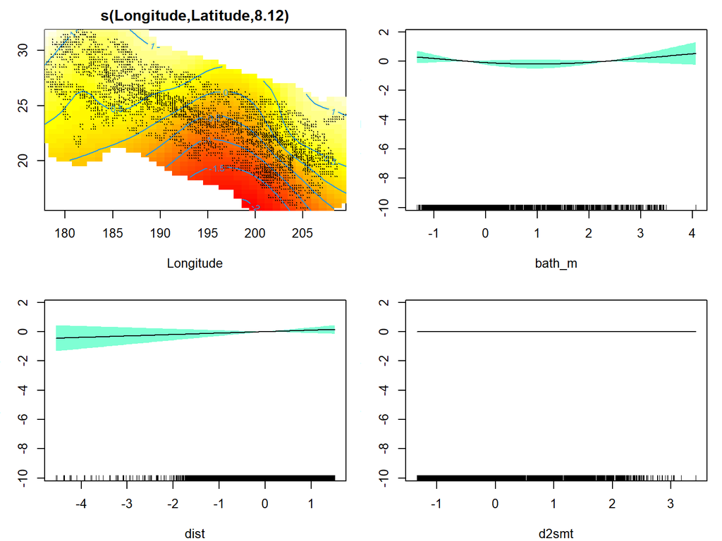

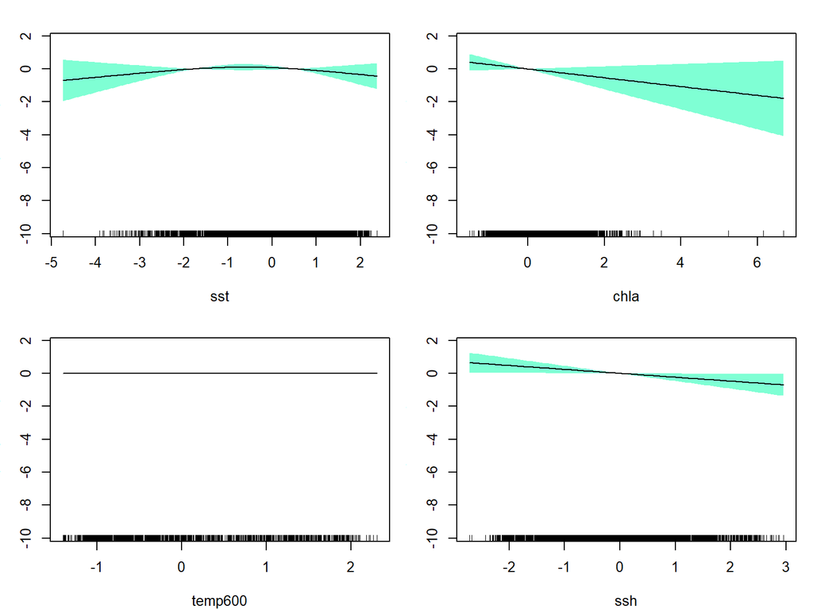

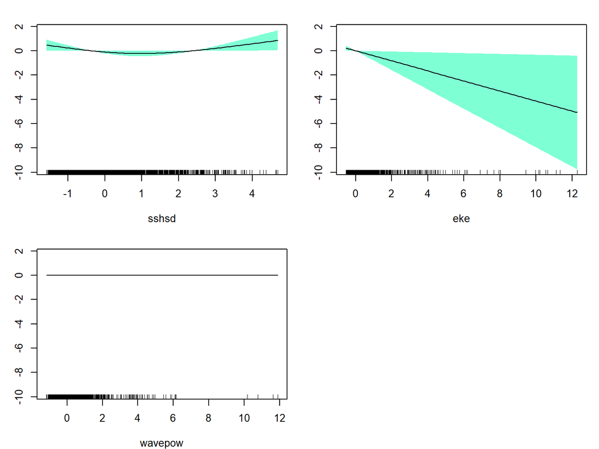

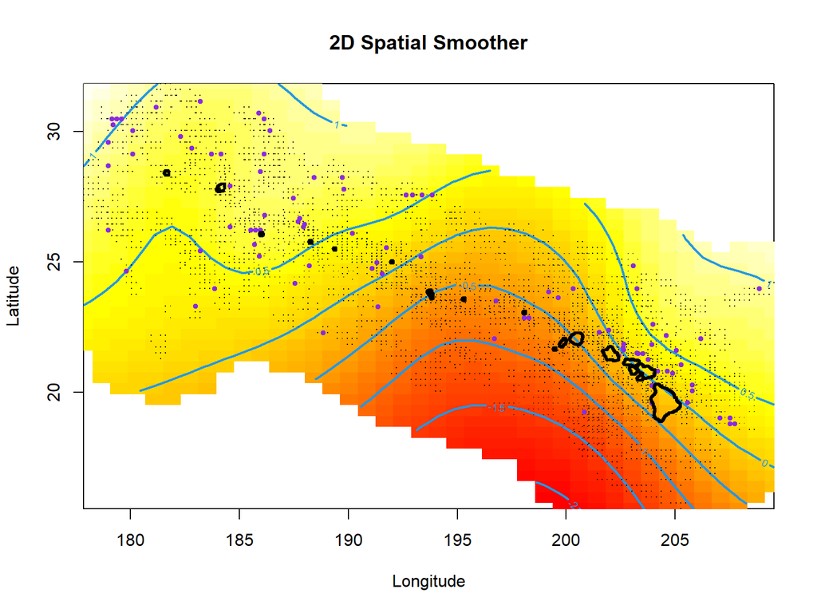

Purple dots represent acoustically detected encounters. Black dots are all data points(grid centroids)

#### MODEL DIAGNOSTICS

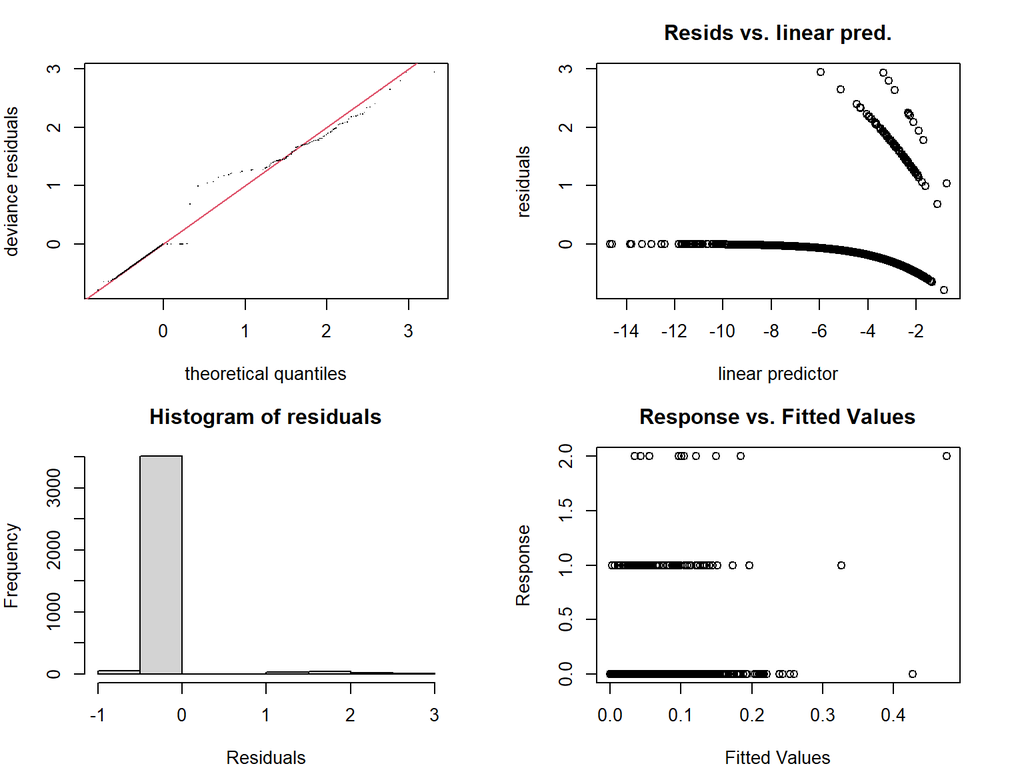

```
Method: REML   Optimizer: outer newton
full convergence after 14 iterations.
Gradient range [-0.0004623193,0.0001049906]
(score 418.7596 & scale 1).
Hessian positive definite, eigenvalue range [2.190574e-06,3.536584].
Model rank =  50 / 50

Basis dimension (k) checking results. Low p-value (k-index<1) may
indicate that k is too low, especially if edf is close to k'.

                            k'      edf k-index p-value
s(Longitude,Latitude) 2.90e+01 8.12e+00    0.80  <2e-16 ***
s(bath_m)             2.00e+00 6.46e-01    0.83   0.090 .
s(dist)               2.00e+00 5.54e-01    0.86   0.640
s(d2smt)              2.00e+00 5.97e-05    0.86   0.665
s(sst)                2.00e+00 5.77e-01    0.82   0.040 *
s(chla)               2.00e+00 7.32e-01    0.85   0.250
s(temp600)            2.00e+00 4.40e-05    0.74  <2e-16 ***
s(ssh)                2.00e+00 8.20e-01    0.84   0.255
s(sshsd)              2.00e+00 8.09e-01    0.82   0.025 *
s(eke)                2.00e+00 8.46e-01    0.84   0.305
s(wavepow)            2.00e+00 2.47e-05    0.79  <2e-16 ***
---
Signif. codes:  0 '***' 0.001 '**' 0.01 '*' 0.05 '.' 0.1 ' ' 1
```

### REDUCE MODEL PARAMETERS

- Keep:
  - Lon, Lat
  - SSH
  - SSHsd
  - EKE

```r
nbS999LLb <- gam(pa ~ s(Longitude, Latitude) + s(ssh, k = 3) +
    s(sshsd, k = 3) + s(eke, k = 3) + offset(log.effort), data = trainS999,
    family = nb, link = "log", select = TRUE, method = "REML")
summary(nbS999LLb)
```

```
Family: Negative Binomial(0.502)
Link function: log

Formula:
pa ~ s(Longitude, Latitude) + s(ssh, k = 3) + s(sshsd, k = 3) +
    s(eke, k = 3) + offset(log.effort)

Parametric coefficients:
            Estimate Std. Error z value Pr(>|z|)
(Intercept) -23.0007     0.1257    -183   <2e-16 ***
---
Signif. codes:  0 '***' 0.001 '**' 0.01 '*' 0.05 '.' 0.1 ' ' 1

Approximate significance of smooth terms:
                         edf Ref.df Chi.sq  p-value
s(Longitude,Latitude) 9.3310     29 38.954 3.24e-07 ***
s(ssh)                0.8082      2  4.178   0.0188 *
s(sshsd)              0.8044      2  4.127   0.0226 *
s(eke)                0.8465      2  4.826   0.0162 *
---
Signif. codes:  0 '***' 0.001 '**' 0.01 '*' 0.05 '.' 0.1 ' ' 1

R-sq.(adj) =  0.0499   Deviance explained = 14.7%
-REML =  419.8  Scale est. = 1         n = 3659
```

Reduced Acoustics Only Model w/ Spatial Smoother

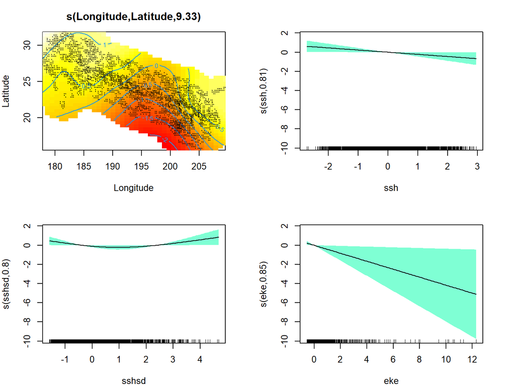

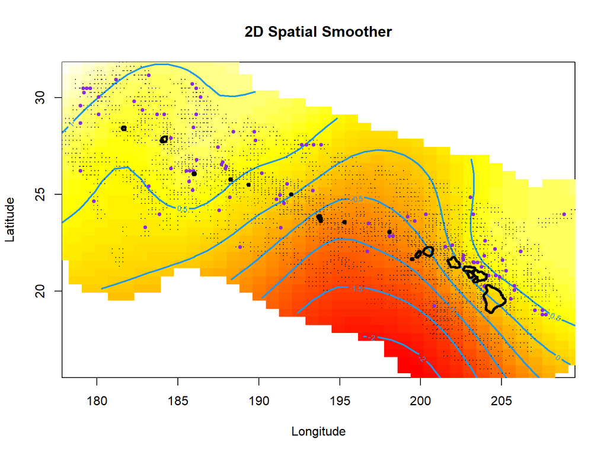

Purple dots represent acoustically detected encounters. Black dots are all data points.

$~$

### Conclusions

##### The final negative binomial models with the spatial smoother yield the same significant variables as the Tweedie models, but with a slightly higher explained deviance, 14.7% compared to 13.5%.

$~$

## Predict Test Data

```r
require(magrittr)
require(dplyr)

#### For twS999c, no spatial smoother ####
nbTrainFinal <- trainS999 %>% mutate(resid = resid(nbS999c),
    predict = predict(nbS999c))
predTrain <- predict.gam(nbS999c, type = "response")  #calculate MSE for these to compare with test set. If they're super different, speaks to the genrality of the model
nbTrainFinal$fit <- predTrain

# using scale of 0,1,2 makes this hard to interpret
nbMSEtrain <- mean((nbTrainFinal$pa - nbTrainFinal$fit)^2)  #MSE
# mean(abs((nbTrainFinal$pa - nbTrainFinal$fit))) #Mean
# absolute error Calculate MSE AFTER transforming the
# predictions back to the same scale as the observed data

nbPred <- predict.gam(nbS999c, newdata = testS999, type = "response",
    se.fit = TRUE)
nbTestFinal <- data.frame(testS999, fit = nbPred$fit, se.fit = nbPred$se.fit)
nbMSEtest <- mean((nbTestFinal$pa - nbTestFinal$fit)^2)  #MSE

# mean(abs((testFinal$pa - testFinal$fit))) #Mean absolute
# error


#### For nbS999cLL, with spatial smoother #### pulling the
#### prediction and residual data from the model
nbTrainLL <- trainS999 %>% mutate(resid = resid(nbS999LLb), predict = predict(nbS999LLb))
predTrainLL <- predict.gam(nbS999LLb, type = "response")  #calculate MSE for these to compare with test set. If they're super different, speaks to the genrality of the model
nbTrainLL$fit <- predTrainLL

# using scale of 0,1,2 makes this hard to interpret
nbMSEtrainLL <- mean((nbTrainLL$pa - nbTrainLL$fit)^2)  #MSE
# mean(abs((nbTrainFinal$pa - nbTrainFinal$fit))) #Mean
# absolute error Calculate MSE AFTER transforming the
# predictions back to the same scale as the observed data

nbPredLL <- predict.gam(nbS999LLb, newdata = testS999, type = "response",
    se.fit = TRUE)
nbTestLL <- data.frame(testS999, fit = nbPredLL$fit, se.fit = nbPredLL$se.fit)
nbMSEtestLL <- mean((nbTestLL$pa - nbTestLL$fit)^2)  #MSE

# mean(abs((testFinal$pa - testFinal$fit))) #Mean absolute
# error

# AIC
nbAIC <- AIC(nbS999c)
nbAICLL <- AIC(nbS999LLb)

# Explained Deviance
nbExpDev = round(((nbS999c$null.deviance - nbS999c$deviance)/nbS999c$null.deviance) *
    100, 2)
nbExpDevLL = round(((nbS999LLb$null.deviance - nbS999LLb$deviance)/nbS999LLb$null.deviance) *
    100, 2)
```

```r
# make summary table of metrics

table = matrix(NA, nrow = 2, ncol = 5)
colnames(table) = c("Model", "ExpDev", "AIC", "MSEtrain", "MSEtest")

# enter info by row

table[1, ] <- c("nbS999c", paste0(nbExpDev, "%"), round(nbAIC,
    2), round(nbMSEtrain, 3), round(nbMSEtest, 3))

table[2, ] <- c("nbS999LLc", paste0(nbExpDevLL, "%"), round(nbAICLL,
    2), round(nbMSEtrainLL, 3), round(nbMSEtestLL, 3))
require(knitr)
kable(table, caption = "Negative Binomial Model Summary Metrics")
```

Negative Binomial Model Summary Metrics

| Model | ExpDev | AIC | MSEtrain | MSEtest |
| --- | --- | --- | --- | --- |
| nbS999c | 8.41% | 849.45 | 0.033 | 0.031 |
| nbS999LLc | 14.74% | 834.36 | 0.032 | 0.03 |

```r
install.packages("countreg", repos = "http://R-Forge.R-project.org")
```

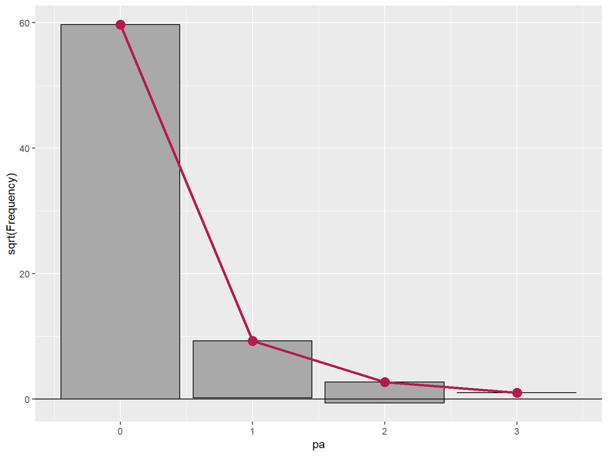

```r
library("countreg")
library("ggplot2")

root1 <- rootogram(nbS999, style = "hanging", plot = FALSE)
autoplot(root1)
```